# **Malaria Detection**

## **Problem Definition**

**The context:** Why is this problem important to solve?  
**The objectives:** What is the intended goal?  
**The key questions:** What are the key questions that need to be answered?  
**The problem formulation:** What is it that we are trying to solve using data science?

## **Data Description**

There are a total of 24,958 train and 2,600 test images (colored) that we have taken from microscopic images. These images are of the following categories:

**Parasitized:** The parasitized cells contain the Plasmodium parasite which causes malaria  
**Uninfected:** The uninfected cells are free of the Plasmodium parasites

Context:

Malaria is a serious and life-threatening disease caused by a parasite that occurs within a cell, with this project, the aim is to detect and differeniate the cells that are parasitized and uninfected. The AI technology that is used to distinguish the two types of cells is CNN, short for convolutional neural network, CNN is a powerful neural network that can take in images from the infected and healthy cells and catagorize them through prediction.

The Objectives:

The objectives of the project is to analyze the initial data and separate them by which ones that are parasitized and uninfected, and taking in the features of what counts as infected or not infected through different types of calculations, then finally using the analyzed data into various CNN models to train and predict the cells that contain malaria and which ones don't.

Key Questions:

Which types of exploratory data analysis should be used within this project?

How large is the training dataset compared to the test dataset?

Which AI architectures should be used?

How to lower time complexity along with high accuracy?

If there was false positives, what measures can be taken?

Would the output prediction be suitable for real-world applications?

Problem Formulation

The scope of the project is to initial the data exploration and define how large the dataset is by using various visualization and data exploration methods, then using the analyzed data to prepare for model training, to then achieve high accuracy prediction through different types of defined CNN architectural models to see which cells are parasitized or not, along with the consideration of the computational limited resources such as CPU and GPU.

### **Mount the Drive**

```python
# connecting to drive
from google.colab import drive
drive.mount('/content/drive')
```

### **Loading libraries**

```python
import zipfile
import os
import numpy as np
import random
import tensorflow as tf
from PIL import Image
import numpy as np
import pandas as pd
import matplotlib.pyplot as plt
import seaborn as sns
from sklearn.model_selection import train_test_split
from sklearn.preprocessing import MinMaxScaler
from keras.preprocessing.image import ImageDataGenerator
from keras.models import Sequential
from keras.layers import Conv2D, MaxPooling2D, Flatten, Dense, Dropout
from keras.optimizers import Adam
from keras.callbacks import EarlyStopping, ModelCheckpoint
from tensorflow.keras import backend
from tensorflow.keras.applications import VGG16
from tensorflow.keras.models import Model
from tensorflow.keras.layers import Dense, Flatten, Dropout, BatchNormalization
from tensorflow.keras.optimizers import Adam
from tensorflow.keras.callbacks import EarlyStopping, ModelCheckpoint, ReduceLROnPlateau
from sklearn.utils.class_weight import compute_class_weight
from tensorflow.keras.preprocessing import image_dataset_from_directory
import warnings
warnings.filterwarnings("ignore")
```

### **Let us load the data**

**Note:**

- You must download the dataset from the link provided on Olympus and upload the same to your Google Drive. Then unzip the folder.

```python
from zipfile import ZipFile
SIZE = 64

zip_path = '/content/drive/MyDrive/training data/cell_images.zip' #path of the dataset
extraction_path = '/content/cell_images' #extraction path for training and testing

with ZipFile(zip_path, 'r') as zip_ref: # extracting the zip file
    zip_ref.extractall(extraction_path)
extraction_path = '/content/cell_images'
#paths for the images
cell_images_path = os.path.join(extraction_path, 'cell_images')
train_dir = os.path.join(cell_images_path, 'train')
test_dir = os.path.join(cell_images_path, 'test')
```

The extracted folder has different folders for train and test data will contain the different sizes of images for parasitized and uninfected cells within the respective folder name.

The size of all images must be the same and should be converted to 4D arrays so that they can be used as an input for the convolutional neural network. Also, we need to create the labels for both types of images to be able to train and test the model.

Let's do the same for the training data first and then we will use the same code for the test data as well.

```python
def load_images_from_folder(folder): #function to check the paths for training and testing dataset
    images = []
    labels = []
    for label in ['parasitized', 'uninfected']:
        label_folder = os.path.join(folder, label)
        print(f"Checking path: {label_folder}")
        if not os.path.exists(label_folder):
            print(f"Label folder {label_folder} does not exist.")
            continue
        files = os.listdir(label_folder)
        print(f"Found {len(files)} files in {label_folder}")
        for i, filename in enumerate(files):
            img_path = os.path.join(label_folder, filename)
            try:
                img = Image.open(img_path)
                img = img.resize((128, 128))  # size of image
                img_array = np.array(img)
                images.append(img_array)
                labels.append(0 if label == 'parasitized' else 1)
            except Exception as e:
                print(f"Error loading image {img_path}: {e}")
    return np.array(images), np.array(labels)
X_train, y_train = load_images_from_folder(train_dir) #training dir
X_test, y_test = load_images_from_folder(test_dir) #test dir
```

```
Checking path: /content/cell_images/cell_images/train/parasitized
Found 12582 files in /content/cell_images/cell_images/train/parasitized
Checking path: /content/cell_images/cell_images/train/uninfected
Found 12376 files in /content/cell_images/cell_images/train/uninfected
Checking path: /content/cell_images/cell_images/test/parasitized
Found 1300 files in /content/cell_images/cell_images/test/parasitized
Checking path: /content/cell_images/cell_images/test/uninfected
Found 1300 files in /content/cell_images/cell_images/test/uninfected
```

### **Check the shape of train and test images**

```python
print(f"Shape of X_train: {X_train.shape}") #shape of x and y train
print(f"Shape of y_train: {y_train.shape}")
```

```
Shape of X_train: (24958, 128, 128, 3)
Shape of y_train: (24958,)
```

### **Check the shape of train and test labels**

```python
parasitized_images = X_train[y_train == 0] #checking the shape of parasitized and uninfected images
uninfected_images = X_train[y_train == 1]
print(f"Shape of parasitized_images: {parasitized_images.shape}")
print(f"Shape of uninfected_images: {uninfected_images.shape}")
```

```
Shape of parasitized_images: (12582, 128, 128, 3)
Shape of uninfected_images: (12376, 128, 128, 3)
```

#### **Observations and insights: theres almost equal balance between the uninfected and parasitized images, with the size of 128,128,3 which is suitable for cnn model training**

### **Check the minimum and maximum range of pixel values for train and test images**

```python
print("Train images - min pixel value:", X_train.min(), "max pixel value:", X_train.max()) #checking the minimum and maximum pixel values with the images
print("Test images - min pixel value:", X_test.min(), "max pixel value:", X_test.max())
```

```
Train images - min pixel value: 0 max pixel value: 255
Test images - min pixel value: 0 max pixel value: 255
```

#### **Observations and insights: Images range from minimum of 0 pixel value to 255 pixel value, this range is good for normmalization and for rescalability when needed.**

### **Count the number of values in both uninfected and parasitized**

```python
num_parasitized = np.sum(y_train == 0) #counting how many uninfected and parasitized images there are within the training datas
num_uninfected = np.sum(y_train == 1)
print(num_parasitized)
print(num_uninfected)
```

```
12582
12376
```

### **Normalize the images**

```python
X_train_normalized = X_train / 255.0 #normalizing the data
X_test_normalized = X_test / 255.0

#verifying the pixel value after normalization
print("Train images - min pixel value:", X_train_normalized.min(), "max pixel value:", X_train_normalized.max())
print("Test images - min pixel value:", X_test_normalized.min(), "max pixel value:", X_test_normalized.max())
```

```
Train images - min pixel value: 0.0 max pixel value: 1.0
Test images - min pixel value: 0.0 max pixel value: 1.0
```

#### **Observations and insights: After the normalization process, the pixel value is ranging between 0 to 1, this will make it easier when training the model since it is standardized and has stability.**

### **Plot to check if the data is balanced**

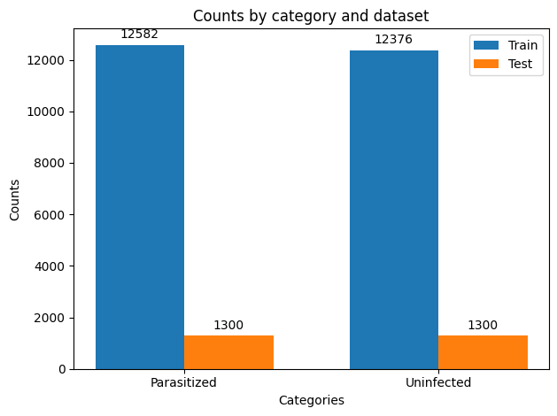

```python
import matplotlib.pyplot as plt

# counting the number of parasitized and uninfected images in the training set
train_counts = [np.sum(y_train == 0), np.sum(y_train == 1)]
test_counts = [np.sum(y_test == 0), np.sum(y_test == 1)]

# Plot the counts
labels = ['Parasitized', 'Uninfected']
x = np.arange(len(labels))
width = 0.35  # bar width

fig, ax = plt.subplots()
rects1 = ax.bar(x - width/2, train_counts, width, label='Train')
rects2 = ax.bar(x + width/2, test_counts, width, label='Test')

# text for the labels and title
ax.set_xlabel('Categories')
ax.set_ylabel('Counts')
ax.set_title('Counts by category and dataset')
ax.set_xticks(x)
ax.set_xticklabels(labels)
ax.legend()

# adding the count above the bars
def add_counts(rects):
    for rect in rects:
        height = rect.get_height()
        ax.annotate('{}'.format(height),
                    xy=(rect.get_x() + rect.get_width() / 2, height),
                    xytext=(0, 3),
                    textcoords="offset points",
                    ha='center', va='bottom')

add_counts(rects1)
add_counts(rects2)

fig.tight_layout()

plt.show()
```

#### **Observations and insights: As shown from the graph, the testing data is equal in the amount of images they contain which is 1300, while the training data has almost equal amount of images. Parasitized being 12582 and uninfected being 12376.**

### **Data Exploration**

Let's visualize the images from the train data

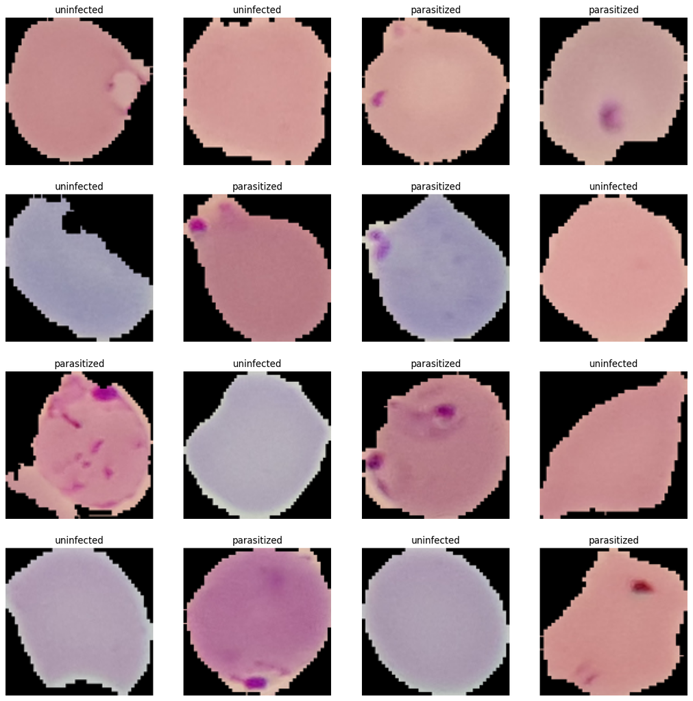

```python
import numpy as np #importing necessary libraries
import matplotlib.pyplot as plt
np.random.seed(42)

plt.figure(1, figsize=(16, 16))
# looping around the image and randomly selecting parasitized or uninfected
for n in range(1, 17):
    plt.subplot(4, 4, n)
    index = np.random.randint(0, X_train_normalized.shape[0])
    if y_train[index] == 0:
        plt.title('parasitized')
    else:
        plt.title('uninfected')
    plt.imshow(X_train_normalized[index])
    plt.axis('off')
```

#### **Observations and insights: From the training dataset, the images shown shows which cells contains the malaria and which ones don't, the ones that don't are labeled as uninfected and the ones that are infected are labeled as parasitized. The parasitized cells have a difference in discoloration, unlike the uninfected cell which does not.**

### **Visualize the images with subplot(6, 6) and figsize = (12, 12)**

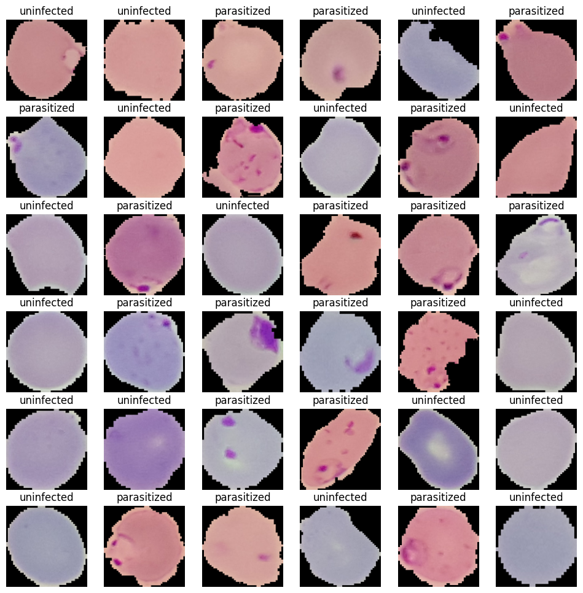

```python
import numpy as np
import matplotlib.pyplot as plt
np.random.seed(42)

plt.figure(1, figsize=(12, 12)) # figure size 12,12

# looping around the image and randomly selecting parasitized or uninfected
for n in range(1, 37):  # (6,6) grid
    plt.subplot(6, 6, n)
    index = np.random.randint(0, X_train_normalized.shape[0])
    if y_train[index] == 0:
        plt.title('parasitized')
    else:
        plt.title('uninfected')
    plt.imshow(X_train_normalized[index])
    plt.axis('off')

plt.show()
```

#### **Observations and insights: The plot is resized to a smaller scale to easily see the 36 images. The images clearly shows which ones are infected and which ones are not. The parasitized have a discolortion on cell and labeled as parasitized, and for uninfected it doesn't have discoloration and it is labeled as uninfected.**

### **Plotting the mean images for parasitized and uninfected**

```python
import numpy as np
import matplotlib.pyplot as plt

# seperating the images by class
parasitized_images = X_train_normalized[y_train == 0]
uninfected_images = X_train_normalized[y_train == 1]

# the mean image for each class
mean_parasitized = np.mean(parasitized_images, axis=0)
mean_uninfected = np.mean(uninfected_images, axis=0)
```

**Mean image for parasitized**

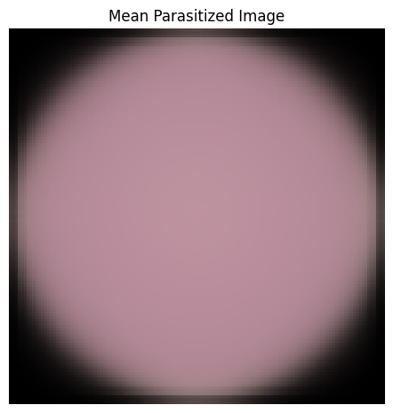

```python
plt.figure(figsize=(12, 6))
# plotting the mean parasitized image
plt.subplot(1, 2, 1)
plt.imshow(mean_parasitized)
plt.title('Mean Parasitized Image')
plt.axis('off')

plt.show()
```

**Mean image for uninfected**

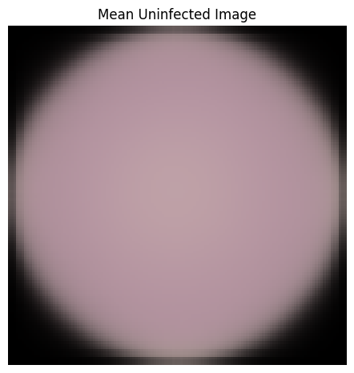

```python
plt.figure(figsize=(12, 6))
# plotting the mean uninfected image
plt.subplot(1, 2, 2)
plt.imshow(mean_uninfected)
plt.title('Mean Uninfected Image')
plt.axis('off')

plt.show()
```

#### **Observations and insights: After getting the mean of parasitized cells and uninfected cells, their individual graphs shows slight difference in color from one another which will be challenging to distinguish the parasitized and uninfected images when training the model.**

### **Converting RGB to HSV of Images using OpenCV**

### **Converting the train data**

```python
import cv2
import numpy as np

# converting images from RGB to HSV
def convert_to_hsv(images):
    hsv_images = []
    for img in images:
        hsv_img = cv2.cvtColor((img * 255).astype(np.uint8), cv2.COLOR_RGB2HSV)
        hsv_images.append(hsv_img)
    return np.array(hsv_images)

# Converting the normalized train images from RGB to HSV
X_train_hsv = convert_to_hsv(X_train_normalized)
```

### **Converting the test data**

```python
X_test_hsv = convert_to_hsv(X_test_normalized)
```

#### **Observations and insights: After importing cv2 library, the conversion of RGB to HSV has been finalized, this is important as the mean image has shown little to no difference, so this measure was needed to help distinguish the uninfected cells and parasitized cells.**

### **Processing Images using Gaussian Blurring**

### **Gaussian Blurring on train data**

```python
import cv2
import numpy as np

# applying the gaussian blurring to the images
def apply_gaussian_blur(images, kernel_size=(5, 5)):
    blurred_images = []
    for img in images:
        blurred_img = cv2.GaussianBlur(img, kernel_size, 0)
        blurred_images.append(blurred_img)
    return np.array(blurred_images)

# applying gaussian blurring to the HSV train images
X_train_blurred = apply_gaussian_blur(X_train_hsv)
```

### **Gaussian Blurring on test data**

```python
X_test_blurred = apply_gaussian_blur(X_test_hsv)
```

#### **Observations and insights: The gaussian blur has been applied to reduce the noise and help enhance the important features within each parasitized and uninfected images. The blurring also helps the model in ignoring little variations within each of the images, this will help the model with its accuracies.**

**Think About It:** Would blurring help us for this problem statement in any way? What else can we try?

## **Model Building**

### **Base Model**

**Note:** The Base Model has been fully built and evaluated with all outputs shown to give an idea about the process of the creation and evaluation of the performance of a CNN architecture. A similar process can be followed in iterating to build better-performing CNN architectures.

### **Importing the required libraries for building and training our Model**

```python
import numpy as np #importing the libraries
import tensorflow as tf
from tensorflow.keras.models import Sequential
from tensorflow.keras.layers import Conv2D, MaxPooling2D, Flatten, Dense, Dropout
from tensorflow.keras.utils import to_categorical
from tensorflow.keras.optimizers import Adam
```

#### **One Hot Encoding the train and test labels**

```python
y_train_one_hot = to_categorical(y_train, num_classes=2) #one hot code each label
y_test_one_hot = to_categorical(y_test, num_classes=2)
```

### **Building the model**

```python
from tensorflow.keras.models import Sequential
from tensorflow.keras.layers import Conv2D, MaxPooling2D, Flatten, Dense, Dropout
from tensorflow.keras.optimizers import Adam

# size
SIZE = 128

# initializing the model
model = Sequential()

# layer with 32 filters, kernel size 3x3, relu activation, and input shape
model.add(Conv2D(32, (3, 3), activation='relu', input_shape=(SIZE, SIZE, 3)))
model.add(MaxPooling2D(pool_size=(2, 2)))

# second layer with 64 filters
model.add(Conv2D(64, (3, 3), activation='relu'))
model.add(MaxPooling2D(pool_size=(2, 2)))

# third layer with 128 filters
model.add(Conv2D(128, (3, 3), activation='relu'))
model.add(MaxPooling2D(pool_size=(2, 2)))

# Flatten the output
model.add(Flatten())

# adding the fully connected layer with 128 units and relu activation
model.add(Dense(128, activation='relu'))

# dropout layer for regularization to prevent overfitting
model.add(Dropout(0.5))

# the output layer with 2 units and softmax activation
model.add(Dense(2, activation='softmax'))

# compiling model
model.compile(optimizer=Adam(), loss='categorical_crossentropy', metrics=['accuracy'])
model.summary()
```

```
Model: "sequential_1"
_________________________________________________________________
 Layer (type)                Output Shape              Param #
=================================================================
 conv2d_4 (Conv2D)           (None, 126, 126, 32)      896

 max_pooling2d_4 (MaxPoolin  (None, 63, 63, 32)        0
 g2D)

 conv2d_5 (Conv2D)           (None, 61, 61, 64)        18496

 max_pooling2d_5 (MaxPoolin  (None, 30, 30, 64)        0
 g2D)

 conv2d_6 (Conv2D)           (None, 28, 28, 128)       73856

 max_pooling2d_6 (MaxPoolin  (None, 14, 14, 128)       0
 g2D)

 flatten_1 (Flatten)         (None, 25088)             0

 dense_3 (Dense)             (None, 128)               3211392

 dropout_2 (Dropout)         (None, 128)               0

 dense_4 (Dense)             (None, 2)                 258

=================================================================
Total params: 3304898 (12.61 MB)
Trainable params: 3304898 (12.61 MB)
Non-trainable params: 0 (0.00 Byte)
_________________________________________________________________
```

### **Compiling the model**

```python
model.compile(optimizer='adam', loss='categorical_crossentropy', metrics=['accuracy']) #compiling the model
model.summary()
```

[output not shown]

**Using Callbacks**

```python
from tensorflow.keras.callbacks import ModelCheckpoint, EarlyStopping, ReduceLROnPlateau
#callbacks for model with defined checkpoint, early stop, and reduce learning rate
checkpoint = ModelCheckpoint("best_model.h5", monitor='val_accuracy', save_best_only=True, mode='max', verbose=1)
early_stop = EarlyStopping(monitor='val_accuracy', patience=10, mode='max', verbose=1)
reduce_lr = ReduceLROnPlateau(monitor='val_accuracy', factor=0.1, patience=5, mode='max', verbose=1)

callbacks_list = [checkpoint, early_stop, reduce_lr]
```

**Fit and train our Model**

```python
history = model.fit(
    X_train_normalized, y_train_one_hot,
    epochs=10,  #  10 epochs because bigger epoches didnt improve accuracies
    batch_size=32,  # batch size
    validation_data=(X_test_normalized, y_test_one_hot),
    callbacks=callbacks_list,  # callbacks here
    verbose=1
    ) # changed the runtime to A100 GPU
```

```
Epoch 1: val_accuracy did not improve from 0.98731
Epoch 2: val_accuracy did not improve from 0.98731
Epoch 3: val_accuracy did not improve from 0.98731
Epoch 4: val_accuracy did not improve from 0.98731
Epoch 5: val_accuracy did not improve from 0.98731
Epoch 6: val_accuracy did not improve from 0.98731
Epoch 7: val_accuracy did not improve from 0.98731
Epoch 8: val_accuracy did not improve from 0.98731

Epoch 8: ReduceLROnPlateau reducing learning rate to 0.00010000000474974513.
Epoch 9: val_accuracy did not improve from 0.98731
Epoch 10: val_accuracy did not improve from 0.98731
```

### **Evaluating the model on test data**

```python
# evaluating the model on test data
test_loss, test_accuracy = model.evaluate(X_test_normalized, y_test_one_hot, verbose=1)

print(f"Test Loss: {test_loss}")
print(f"Test Accuracy: {test_accuracy}")
```

```
Test Loss: 0.09584707021713257
Test Accuracy: 0.9830769300460815
```

**Plotting the confusion matrix**

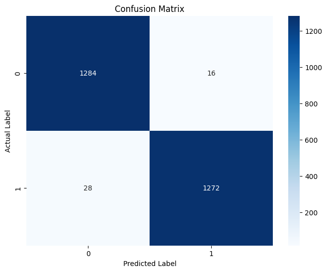

```python
from sklearn.metrics import confusion_matrix
import seaborn as sns

# predict the labels for the test dataset
y_pred = model.predict(X_test_normalized)
y_pred_classes = np.argmax(y_pred, axis=1)
y_true = np.argmax(y_test_one_hot, axis=1)

# confusion matrix
conf_matrix = confusion_matrix(y_true, y_pred_classes)

# plot of the confusion matrix
plt.figure(figsize=(8, 6))
sns.heatmap(conf_matrix, annot=True, fmt="d", cmap="Blues")
plt.title('Confusion Matrix')
plt.ylabel('Actual Label')
plt.xlabel('Predicted Label')
plt.show()
```

**Plotting the train and validation curves**

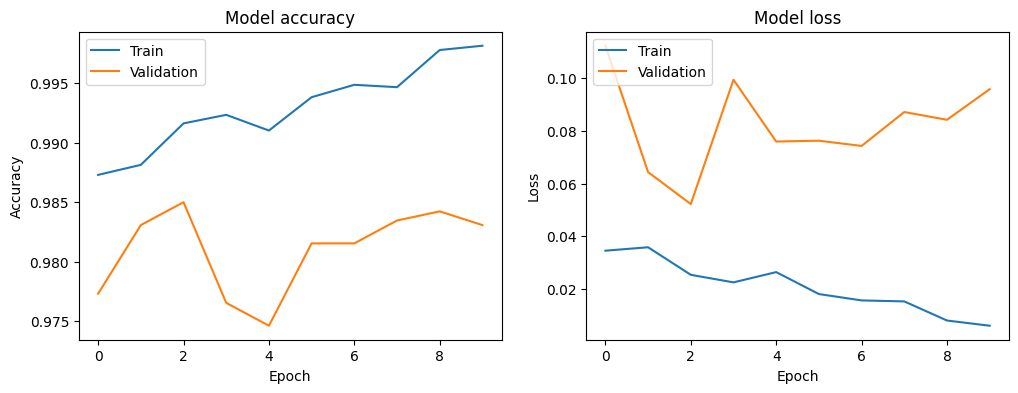

```python
# plotting the accuracy
plt.figure(figsize=(12, 4))

plt.subplot(1, 2, 1)
plt.plot(history.history['accuracy'])
plt.plot(history.history['val_accuracy'])
plt.title('Model accuracy')
plt.ylabel('Accuracy')
plt.xlabel('Epoch')
plt.legend(['Train', 'Validation'], loc='upper left')

# plotting the loss
plt.subplot(1, 2, 2)
plt.plot(history.history['loss'])
plt.plot(history.history['val_loss'])
plt.title('Model loss')
plt.ylabel('Loss')
plt.xlabel('Epoch')
plt.legend(['Train', 'Validation'], loc='upper left')

plt.show()
```

So now let's try to build another model with few more add on layers and try to check if we can try to improve the model. Therefore try to build a model by adding few layers if required and altering the activation functions.

### **Model 1**

#### **Trying to improve the performance of our model by adding new layers**

```python
# importing necessary libraries
import numpy as np
import tensorflow as tf
from tensorflow.keras.models import Sequential
from tensorflow.keras.layers import Conv2D, MaxPooling2D, Flatten, Dense, Dropout
from tensorflow.keras.optimizers import Adam

# Initialize the model
model1 = Sequential()
```

### **Building the Model**

```python
# adding layers
model1.add(Conv2D(32, (3, 3), activation='relu', input_shape=(128, 128, 3)))
model1.add(MaxPooling2D(pool_size=(2, 2)))

model1.add(Conv2D(64, (3, 3), activation='relu'))
model1.add(MaxPooling2D(pool_size=(2, 2)))

model1.add(Conv2D(128, (3, 3), activation='relu'))
model1.add(MaxPooling2D(pool_size=(2, 2)))

model1.add(Conv2D(256, (3, 3), activation='relu'))
model1.add(MaxPooling2D(pool_size=(2, 2)))

# flattening the output
model1.add(Flatten())

# adding a fully connected layers
model1.add(Dense(256, activation='relu'))
model1.add(Dropout(0.5))

model1.add(Dense(128, activation='relu'))
model1.add(Dropout(0.5))

# the output layer with 2 units and softmax activation
model1.add(Dense(2, activation='softmax'))
```

### **Compiling the model**

```python
# compiling the model and displaying
model1.compile(optimizer=Adam(), loss='categorical_crossentropy', metrics=['accuracy'])
model1.summary()
```

```
Model: "sequential"
_________________________________________________________________
 Layer (type)                Output Shape              Param #
=================================================================
 conv2d (Conv2D)             (None, 126, 126, 32)      896

 max_pooling2d (MaxPooling2  (None, 63, 63, 32)        0
 D)

 conv2d_1 (Conv2D)           (None, 61, 61, 64)        18496

 max_pooling2d_1 (MaxPoolin  (None, 30, 30, 64)        0
 g2D)

 conv2d_2 (Conv2D)           (None, 28, 28, 128)       73856

 max_pooling2d_2 (MaxPoolin  (None, 14, 14, 128)       0
 g2D)

 conv2d_3 (Conv2D)           (None, 12, 12, 256)       295168

 max_pooling2d_3 (MaxPoolin  (None, 6, 6, 256)         0
 g2D)

 flatten (Flatten)           (None, 9216)              0

 dense (Dense)               (None, 256)               2359552

 dropout (Dropout)           (None, 256)               0

 dense_1 (Dense)             (None, 128)               32896

 dropout_1 (Dropout)         (None, 128)               0

 dense_2 (Dense)             (None, 2)                 258

=================================================================
Total params: 2781122 (10.61 MB)
Trainable params: 2781122 (10.61 MB)
Non-trainable params: 0 (0.00 Byte)
_________________________________________________________________
```

**Using Callbacks**

```python
from tensorflow.keras.callbacks import ModelCheckpoint, EarlyStopping

# defining the callbacks
checkpoint = ModelCheckpoint("model1_best.h5", monitor='val_accuracy', save_best_only=True, mode='max')
early_stopping = EarlyStopping(monitor='val_loss', patience=5, restore_best_weights=True)

callbacks_list = [checkpoint, early_stopping]
```

**Fit and Train the model**

```python
history = model1.fit(
    X_train_normalized, y_train_one_hot,
    epochs=10,  # 50 epochs
    batch_size=32,  # batch size 32
    validation_data=(X_test_normalized, y_test_one_hot),
    callbacks=callbacks_list,  # callbacks
    verbose=1
) # using A100
```

### **Evaluating the model**

```python
# evaluating the model on test
score = model1.evaluate(X_test_normalized, y_test_one_hot, verbose=0)
print('Test loss:', score[0])
print('Test accuracy:', score[1])
y_pred_prob1 = model1.predict(X_test_normalized)
y_pred1 = np.argmax(y_pred_prob1, axis=1)
print(y_pred1)
```

```
Test loss: 0.043081965297460556
Test accuracy: 0.9876922965049744
[0 0 0 ... 1 1 1]
```

**Plotting the confusion matrix**

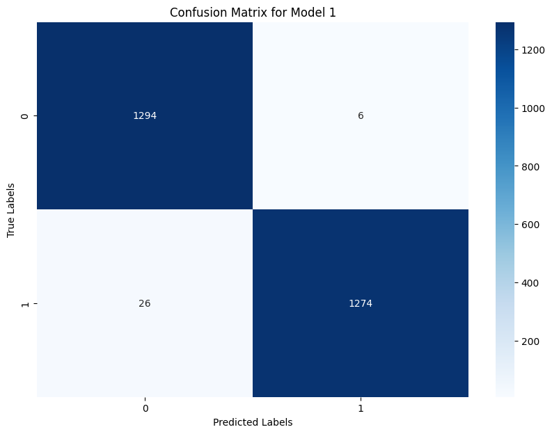

```python
from sklearn.metrics import confusion_matrix
import seaborn as sns
conf_matrix1 = confusion_matrix(np.argmax(y_test_one_hot, axis=1), y_pred1)
# plotting the confusion matrix
plt.figure(figsize=(10, 7))
sns.heatmap(conf_matrix1, annot=True, fmt='d', cmap='Blues')
plt.xlabel('Predicted Labels')
plt.ylabel('True Labels')
plt.title('Confusion Matrix for Model 1')
plt.show()
```

**Plotting the train and the validation curves**

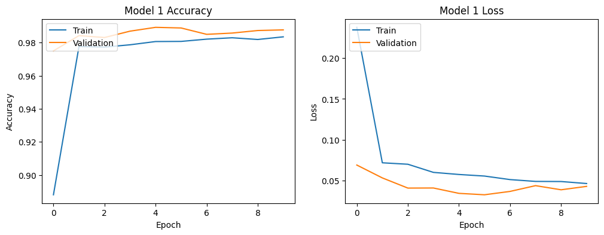

```python
# plotting the accuracy values
plt.figure(figsize=(12, 4))

plt.subplot(1, 2, 1)
plt.plot(history.history['accuracy'])
plt.plot(history.history['val_accuracy'])
plt.title('Model 1 Accuracy')
plt.ylabel('Accuracy')
plt.xlabel('Epoch')
plt.legend(['Train', 'Validation'], loc='upper left')

# plotting the loss values
plt.subplot(1, 2, 2)
plt.plot(history.history['loss'])
plt.plot(history.history['val_loss'])
plt.title('Model 1 Loss')
plt.ylabel('Loss')
plt.xlabel('Epoch')
plt.legend(['Train', 'Validation'], loc='upper left')

plt.show()
```

### **Think about it:**

Now let's build a model with LeakyRelu as the activation function

- Can the model performance be improved if we change our activation function to LeakyRelu?
- Can BatchNormalization improve our model?

Let us try to build a model using BatchNormalization and using LeakyRelu as our activation function.

### **Model 2 with Batch Normalization**

```python
from keras.layers import LeakyReLU, BatchNormalization #adding batch normalization from keras.layers

# initializing the model
model2 = Sequential()
```

### **Building the Model**

```python
#defining the model with size 128,128,3 with batch normalization
model2.add(Conv2D(32, (3, 3), input_shape=(128, 128, 3)))
model2.add(BatchNormalization())
model2.add(LeakyReLU(alpha=0.1))
model2.add(MaxPooling2D(pool_size=(2, 2)))

model2.add(Conv2D(64, (3, 3)))
model2.add(BatchNormalization())
model2.add(LeakyReLU(alpha=0.1))
model2.add(MaxPooling2D(pool_size=(2, 2)))

model2.add(Conv2D(128, (3, 3)))
model2.add(BatchNormalization())
model2.add(LeakyReLU(alpha=0.1))
model2.add(MaxPooling2D(pool_size=(2, 2)))

model2.add(Conv2D(256, (3, 3)))
model2.add(BatchNormalization())
model2.add(LeakyReLU(alpha=0.1))
model2.add(MaxPooling2D(pool_size=(2, 2)))

# flatten
model2.add(Flatten())

# fully connected layers with batch normalization and leakyrelu
model2.add(Dense(128))
model2.add(BatchNormalization())
model2.add(LeakyReLU(alpha=0.1))
model2.add(Dropout(0.5))

model2.add(Dense(64))
model2.add(BatchNormalization())
model2.add(LeakyReLU(alpha=0.1))
model2.add(Dropout(0.5))

# adding the output layer
model2.add(Dense(2, activation='softmax'))
```

### **Compiling the model**

```python
model2.compile(optimizer=Adam(), loss='categorical_crossentropy', metrics=['accuracy']) #compiling the model
model2.summary()
```

```
Model: "sequential_2"
_________________________________________________________________
 Layer (type)                Output Shape              Param #
=================================================================
 conv2d_7 (Conv2D)           (None, 126, 126, 32)      896

 batch_normalization (Batch  (None, 126, 126, 32)      128
 Normalization)

 leaky_re_lu (LeakyReLU)     (None, 126, 126, 32)      0

 max_pooling2d_7 (MaxPoolin  (None, 63, 63, 32)        0
 g2D)

 conv2d_8 (Conv2D)           (None, 61, 61, 64)        18496

 batch_normalization_1 (Bat  (None, 61, 61, 64)        256
 chNormalization)

 leaky_re_lu_1 (LeakyReLU)   (None, 61, 61, 64)        0

 max_pooling2d_8 (MaxPoolin  (None, 30, 30, 64)        0
 g2D)

 conv2d_9 (Conv2D)           (None, 28, 28, 128)       73856

 batch_normalization_2 (Bat  (None, 28, 28, 128)       512
 chNormalization)

 leaky_re_lu_2 (LeakyReLU)   (None, 28, 28, 128)       0

 max_pooling2d_9 (MaxPoolin  (None, 14, 14, 128)       0
 g2D)

 conv2d_10 (Conv2D)          (None, 12, 12, 256)       295168

 batch_normalization_3 (Bat  (None, 12, 12, 256)       1024
 chNormalization)

 leaky_re_lu_3 (LeakyReLU)   (None, 12, 12, 256)       0
```

[output cut: 16 more lines]

```

 batch_normalization_5 (Bat  (None, 64)                256
 chNormalization)

 leaky_re_lu_5 (LeakyReLU)   (None, 64)                0

 dropout_4 (Dropout)         (None, 64)                0

 dense_7 (Dense)             (None, 2)                 130

=================================================================
Total params: 1579266 (6.02 MB)
Trainable params: 1577922 (6.02 MB)
Non-trainable params: 1344 (5.25 KB)
_________________________________________________________________
```

**Using callbacks**

```python
# callbacks
early_stopping2 = EarlyStopping(monitor='val_loss', patience=10, restore_best_weights=True)
reduce_lr2 = ReduceLROnPlateau(monitor='val_loss', factor=0.2, patience=5, min_lr=0.0001)
model_checkpoint2 = ModelCheckpoint('best_model2.h5', monitor='val_loss', save_best_only=True)

callbacks_list2 = [early_stopping2, reduce_lr2, model_checkpoint2]
```

**Fit and train the model**

```python
history2 = model2.fit(
    X_train_normalized, y_train_one_hot,
    epochs=50, # 10 epochs
    batch_size=32, #batch size
    validation_data=(X_test_normalized, y_test_one_hot),
    callbacks=callbacks_list2, # callbacks
    verbose=1
) #using A100 gpu
```

**Plotting the train and validation accuracy**

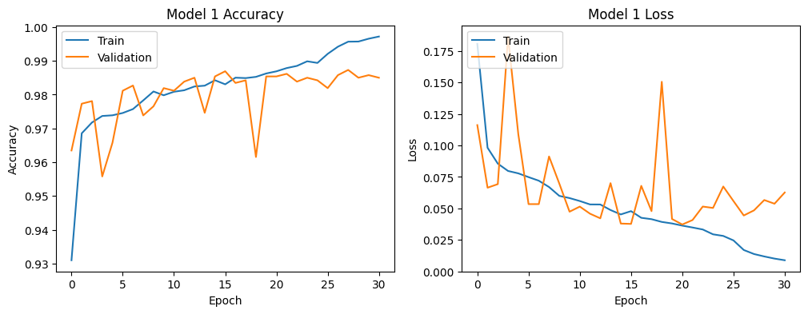

```python
# plotting accuracy
plt.figure(figsize=(12, 4))

plt.subplot(1, 2, 1)
plt.plot(history2.history['accuracy'])
plt.plot(history2.history['val_accuracy'])
plt.title('Model 1 Accuracy')
plt.ylabel('Accuracy')
plt.xlabel('Epoch')
plt.legend(['Train', 'Validation'], loc='upper left')

# plotting loss values
plt.subplot(1, 2, 2)
plt.plot(history2.history['loss'])
plt.plot(history2.history['val_loss'])
plt.title('Model 1 Loss')
plt.ylabel('Loss')
plt.xlabel('Epoch')
plt.legend(['Train', 'Validation'], loc='upper left')

plt.show()
```

### **Evaluating the model**

```python
# evaluating the model on the test dataset images
score2 = model2.evaluate(X_test_normalized, y_test_one_hot, verbose=0)
print('Test loss:', score2[0])
print('Test accuracy:', score2[1])
```

```
Test loss: 0.037180304527282715
Test accuracy: 0.9853846430778503
```

#### **Observations and insights: After using the model with batch noramlization, the evaulated model shows a great accuracy of 98% with the test dataset, which is a good sign that the model preformed very well.**

**Generate the classification report and confusion matrix**

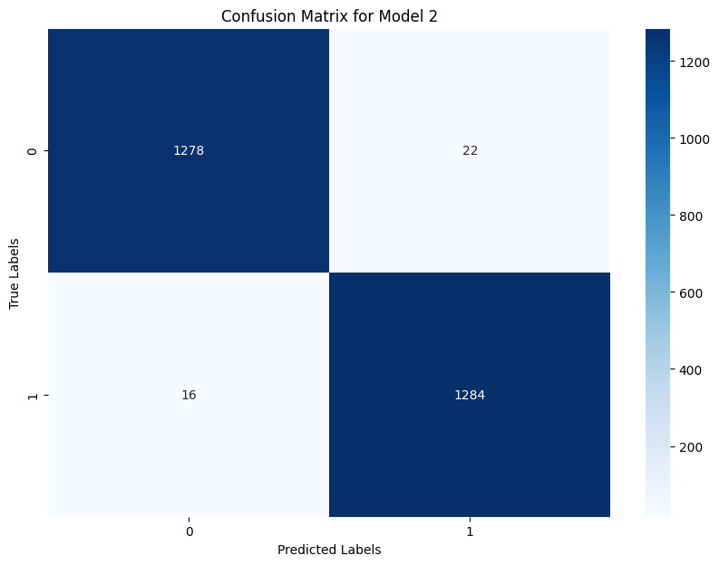

```python
# labels
y_pred_prob2 = model2.predict(X_test_normalized)
y_pred2 = np.argmax(y_pred_prob2, axis=1)

# confusion matrix
conf_matrix2 = confusion_matrix(np.argmax(y_test_one_hot, axis=1), y_pred2)

# Plotting
plt.figure(figsize=(10, 7))
sns.heatmap(conf_matrix2, annot=True, fmt='d', cmap='Blues')
plt.xlabel('Predicted Labels')
plt.ylabel('True Labels')
plt.title('Confusion Matrix for Model 2')
plt.show()
```

### **Think About It :**

- Can we improve the model with Image Data Augmentation?
- References to image data augmentation can be seen below:
  - [Image Augmentation for Computer Vision](https://www.mygreatlearning.com/blog/understanding-data-augmentation/)
  - [How to Configure Image Data Augmentation in Keras?](https://machinelearningmastery.com/how-to-configure-image-data-augmentation-when-training-deep-learning-neural-networks/)

### **Model 3 with Data Augmentation**

```python
#libraries
from keras.preprocessing.image import ImageDataGenerator
from keras.models import Sequential
from keras.layers import Conv2D, MaxPooling2D, Flatten, Dense, Dropout
from keras.optimizers import Adam
from keras.callbacks import EarlyStopping, ModelCheckpoint
```

### **Use image data generator**

```python
# data augmentation
train_datagen = ImageDataGenerator(
    rescale=1./255,
    rotation_range=15,
    width_shift_range=0.1,
    height_shift_range=0.1,
    shear_range=0.1,
    zoom_range=0.1,
    horizontal_flip=True,
    fill_mode='nearest'
)

test_datagen = ImageDataGenerator(rescale=1./255)

train_generator = train_datagen.flow(X_train_normalized, y_train_one_hot, batch_size=32)
validation_generator = test_datagen.flow(X_test_normalized, y_test_one_hot, batch_size=32)
```

### **Think About It :**

- Check if the performance of the model can be improved by changing different parameters in the ImageDataGenerator.

#### **Visualizing Augmented images**

```
Augmented images shape: (32, 128, 128, 3)
Min pixel value: 0.0
Max pixel value: 0.0038633961
```

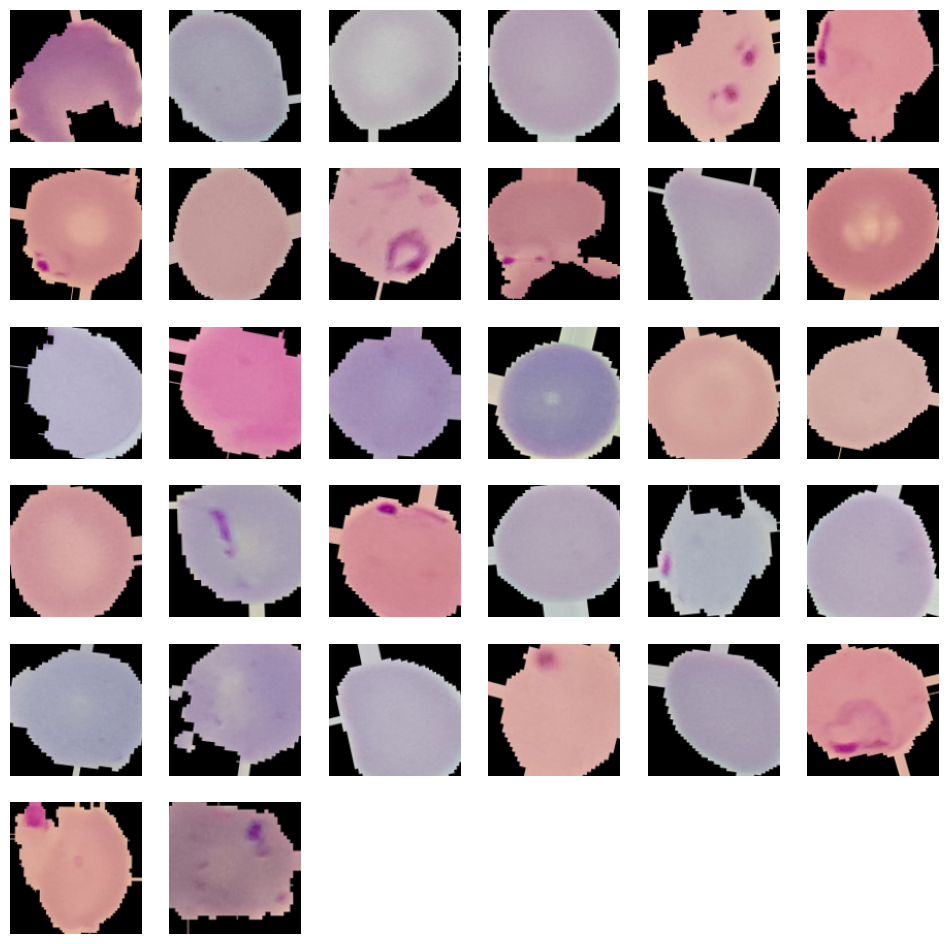

```python
import numpy as np
import matplotlib.pyplot as plt

# generating the batch of images
augmented_images, _ = next(train_generator)

# printing the details about the augmented images
print("Augmented images shape:", augmented_images.shape)
print("Min pixel value:", augmented_images.min())
print("Max pixel value:", augmented_images.max())

# rescaling images to 0,1 range for visualization
augmented_images_rescaled = augmented_images / augmented_images.max()

# plotting the augmented images
plt.figure(figsize=(12, 12))

for i in range(min(36, augmented_images_rescaled.shape[0])):  # displaying 36 images
    plt.subplot(6, 6, i + 1)
    plt.imshow(augmented_images_rescaled[i])
    plt.axis('off')

plt.show()
```

#### **Observations and insights: The images shown after augumentation shows that there is differences in the images by their rotations, zooms, and shift. The importance of the augumentation will help the model to generalize when it comes to training.**

### **Building the Model**

```python
#building model for the augumented images
model3 = Sequential([
    Conv2D(32, (3, 3), activation='relu', input_shape=(128, 128, 3)),
    MaxPooling2D(pool_size=(2, 2)),
    Conv2D(64, (3, 3), activation='relu'),
    MaxPooling2D(pool_size=(2, 2)),
    Conv2D(128, (3, 3), activation='relu'),
    MaxPooling2D(pool_size=(2, 2)),
    Flatten(),
    Dense(128, activation='relu'),
    Dropout(0.5),
    Dense(2, activation='softmax')
])

# compiling
model3.compile(optimizer=Adam(learning_rate=0.0001), loss='categorical_crossentropy', metrics=['accuracy'])
model3.summary()
```

```
Model: "sequential_7"
_________________________________________________________________
 Layer (type)                Output Shape              Param #
=================================================================
 conv2d_23 (Conv2D)          (None, 126, 126, 32)      896

 max_pooling2d_23 (MaxPooli  (None, 63, 63, 32)        0
 ng2D)

 conv2d_24 (Conv2D)          (None, 61, 61, 64)        18496

 max_pooling2d_24 (MaxPooli  (None, 30, 30, 64)        0
 ng2D)

 conv2d_25 (Conv2D)          (None, 28, 28, 128)       73856

 max_pooling2d_25 (MaxPooli  (None, 14, 14, 128)       0
 ng2D)

 flatten_7 (Flatten)         (None, 25088)             0

 dense_16 (Dense)            (None, 128)               3211392

 dropout_9 (Dropout)         (None, 128)               0

 dense_17 (Dense)            (None, 2)                 258

=================================================================
Total params: 3304898 (12.61 MB)
Trainable params: 3304898 (12.61 MB)
Non-trainable params: 0 (0.00 Byte)
_________________________________________________________________
```

**Using Callbacks**

```python
callbacks_list = [ #defining callbacks
    EarlyStopping(monitor='val_loss', patience=5),
    ModelCheckpoint(filepath='best_model.h5', monitor='val_loss', save_best_only=True)
]
```

**Fit and Train the model**

```python
history3 = model3.fit( #training the model
    train_generator, #defined generator for training
    epochs=50, # 50 epochs
    validation_data=validation_generator,
    callbacks=callbacks_list,
    verbose=1
)
```

### **Evaluating the model**

**Plot the train and validation accuracy**

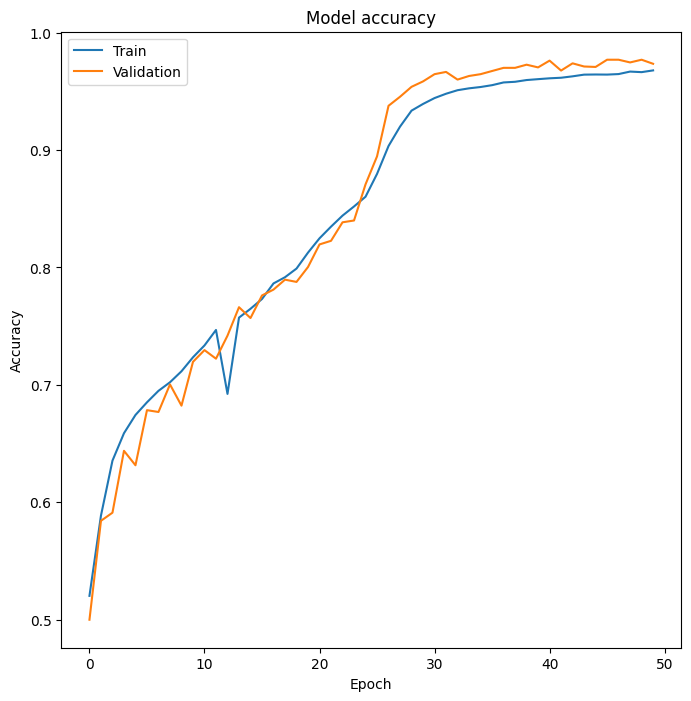

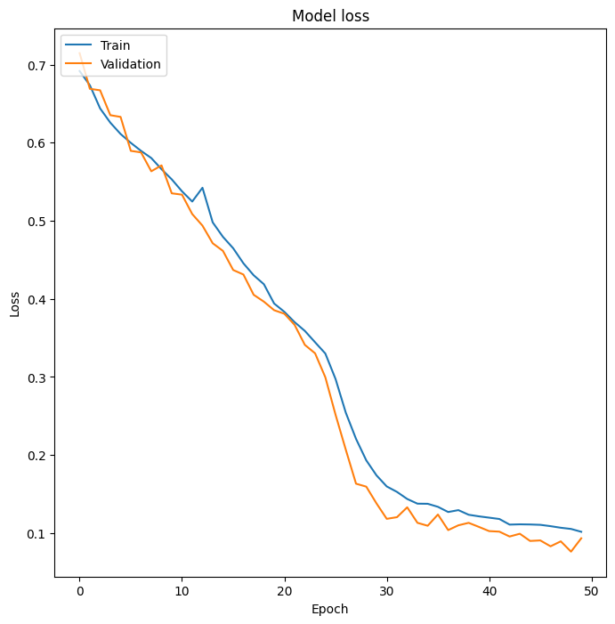

```python
import matplotlib.pyplot as plt

# plotting the accuracies within the model
plt.figure(figsize=(8, 8))
plt.plot(history3.history['accuracy'])
plt.plot(history3.history['val_accuracy'])
plt.title('Model accuracy')
plt.ylabel('Accuracy')
plt.xlabel('Epoch')
plt.legend(['Train', 'Validation'], loc='upper left')
plt.show()

# plotting the loss values for the model
plt.figure(figsize=(8, 8))
plt.plot(history3.history['loss'])
plt.plot(history3.history['val_loss'])
plt.title('Model loss')
plt.ylabel('Loss')
plt.xlabel('Epoch')
plt.legend(['Train', 'Validation'], loc='upper left')
plt.show()
```

**Plotting the classification report and confusion matrix**

```
              precision    recall  f1-score   support

  Uninfected       0.97      0.98      0.97      1294
 Parasitized       0.98      0.96      0.97      1306

    accuracy                           0.97      2600
   macro avg       0.97      0.97      0.97      2600
weighted avg       0.97      0.97      0.97      2600
```

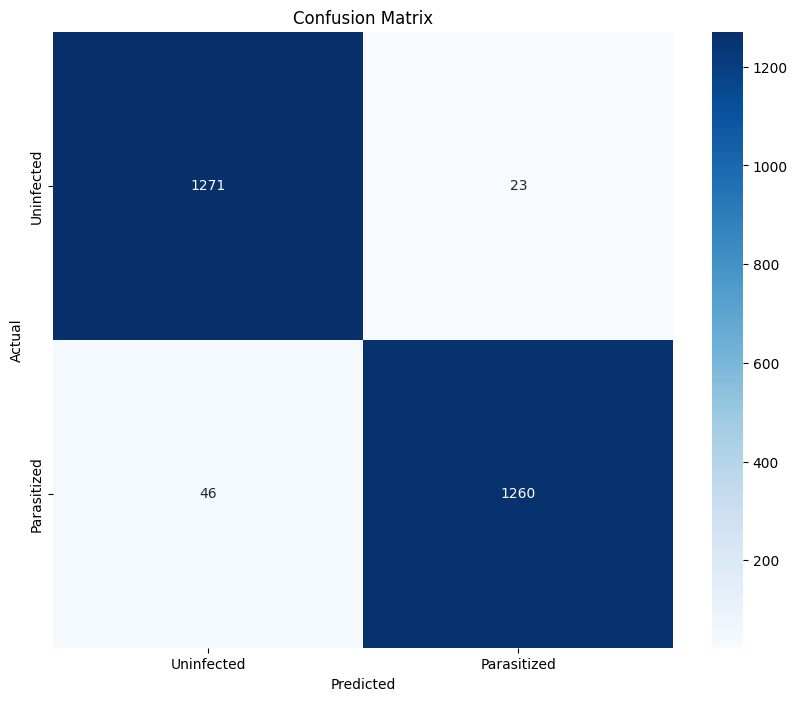

```python
from sklearn.metrics import classification_report, confusion_matrix
import seaborn as sns
import matplotlib.pyplot as plt

# lists for true_labels and predictions
true_labels = []
predictions = []

# looping through the validation generator
for i, (images, labels) in enumerate(validation_generator):
    preds = model3.predict(images, verbose=0)  # setting the verbose to 0 to suppress output
    true_labels.append(labels)
    predictions.append(preds)

    # breaking the loop if we've processed all batches
    if i >= len(validation_generator) - 1:
        break

# convert lists to arrays
true_labels = np.concatenate(true_labels)
predictions = np.concatenate(predictions)

# getting the class predictions
y_true_classes = np.argmax(true_labels, axis=1)
y_pred_classes = np.argmax(predictions, axis=1)

# classification report
report = classification_report(y_true_classes, y_pred_classes, target_names=['Uninfected', 'Parasitized'])
print(report)

# the confusion matrix
conf_matrix = confusion_matrix(y_true_classes, y_pred_classes)

# Plot for the confusion matrix
plt.figure(figsize=(10, 8))
sns.heatmap(conf_matrix, annot=True, fmt='d', cmap='Blues', xticklabels=['Uninfected', 'Parasitized'], yticklabels=['Uninfected', 'Parasitized'])
plt.ylabel('Actual')
plt.xlabel('Predicted')
plt.title('Confusion Matrix')
plt.show()
```

**Now, let us try to use a pretrained model like VGG16 and check how it performs on our data.**

### **Pre-trained model (VGG16)**

- Import VGG16 network upto any layer you choose
- Add Fully Connected Layers on top of it

```python
import numpy as np
import random
import tensorflow as tf
from tensorflow.keras import backend
from tensorflow.keras.applications import VGG16
from tensorflow.keras.models import Model
from tensorflow.keras.layers import Dense, Flatten, Dropout, BatchNormalization
from tensorflow.keras.optimizers import Adam
from tensorflow.keras.callbacks import EarlyStopping, ModelCheckpoint, ReduceLROnPlateau
from sklearn.utils.class_weight import compute_class_weight
import matplotlib.pyplot as plt
from tensorflow.keras.preprocessing import image_dataset_from_directory

# clearing backend
backend.clear_session()

# seed for random number generator
np.random.seed(42)
random.seed(42)
tf.random.set_seed(42)

# Loading the data

train_dataset = image_dataset_from_directory(train_dir,
                                             image_size=(64, 64),
                                             batch_size=64,
                                             label_mode='categorical')

test_dataset = image_dataset_from_directory(test_dir,
                                            image_size=(64, 64),
                                            batch_size=64,
                                            label_mode='categorical')

# normalizing the data
def normalize(image, label):
    image = tf.cast(image, tf.float32) / 255.0
    return image, label

train_dataset = train_dataset.map(normalize)
test_dataset = test_dataset.map(normalize)
```

```
Found 24958 files belonging to 2 classes.
Found 2600 files belonging to 2 classes.
```

```python
#defining labels for vgg16 model along with class weights
y_train_labels = np.concatenate([y for x, y in train_dataset], axis=0)
y_train_labels = np.argmax(y_train_labels, axis=1)
class_weights = compute_class_weight(class_weight='balanced', classes=np.unique(y_train_labels), y=y_train_labels)
class_weights = dict(enumerate(class_weights))
```

```python
vgg = VGG16(include_top=False, weights='imagenet', input_shape=(64, 64, 3))
vgg.summary()

# Uufreezing specific layers if needed
for layer in vgg.layers[-4:]:
    layer.trainable = False

# getting the output of a specific layer
transfer_layer = vgg.get_layer('block5_pool').output

# custom classification layers
x = Flatten()(transfer_layer)
x = Dense(256, activation='relu')(x)
x = Dropout(0.3)(x)
x = Dense(128, activation='relu')(x)
x = Dropout(0.3)(x)
x = Dense(64, activation='relu')(x)
x = BatchNormalization()(x)
pred = Dense(2, activation='softmax')(x)

model4 = Model(inputs=vgg.input, outputs=pred)
```

```
Model: "vgg16"
_________________________________________________________________
 Layer (type)                Output Shape              Param #
=================================================================
 input_1 (InputLayer)        [(None, 64, 64, 3)]       0

 block1_conv1 (Conv2D)       (None, 64, 64, 64)        1792

 block1_conv2 (Conv2D)       (None, 64, 64, 64)        36928

 block1_pool (MaxPooling2D)  (None, 32, 32, 64)        0

 block2_conv1 (Conv2D)       (None, 32, 32, 128)       73856

 block2_conv2 (Conv2D)       (None, 32, 32, 128)       147584

 block2_pool (MaxPooling2D)  (None, 16, 16, 128)       0

 block3_conv1 (Conv2D)       (None, 16, 16, 256)       295168

 block3_conv2 (Conv2D)       (None, 16, 16, 256)       590080

 block3_conv3 (Conv2D)       (None, 16, 16, 256)       590080

 block3_pool (MaxPooling2D)  (None, 8, 8, 256)         0

 block4_conv1 (Conv2D)       (None, 8, 8, 512)         1180160

 block4_conv2 (Conv2D)       (None, 8, 8, 512)         2359808

 block4_conv3 (Conv2D)       (None, 8, 8, 512)         2359808

 block4_pool (MaxPooling2D)  (None, 4, 4, 512)         0

 block5_conv1 (Conv2D)       (None, 4, 4, 512)         2359808

 block5_conv2 (Conv2D)       (None, 4, 4, 512)         2359808

 block5_conv3 (Conv2D)       (None, 4, 4, 512)         2359808

 block5_pool (MaxPooling2D)  (None, 2, 2, 512)         0

=================================================================
Total params: 14714688 (56.13 MB)
Trainable params: 14714688 (56.13 MB)
Non-trainable params: 0 (0.00 Byte)
_________________________________________________________________
```

### **Compiling the model**

```python
# compiling the model
model4.compile(optimizer=Adam(learning_rate=1e-5), loss='categorical_crossentropy', metrics=['accuracy'])

# display model summary
model4.summary()
```

```
Model: "model"
_________________________________________________________________
 Layer (type)                Output Shape              Param #
=================================================================
 input_1 (InputLayer)        [(None, 64, 64, 3)]       0

 block1_conv1 (Conv2D)       (None, 64, 64, 64)        1792

 block1_conv2 (Conv2D)       (None, 64, 64, 64)        36928

 block1_pool (MaxPooling2D)  (None, 32, 32, 64)        0

 block2_conv1 (Conv2D)       (None, 32, 32, 128)       73856

 block2_conv2 (Conv2D)       (None, 32, 32, 128)       147584

 block2_pool (MaxPooling2D)  (None, 16, 16, 128)       0

 block3_conv1 (Conv2D)       (None, 16, 16, 256)       295168

 block3_conv2 (Conv2D)       (None, 16, 16, 256)       590080

 block3_conv3 (Conv2D)       (None, 16, 16, 256)       590080

 block3_pool (MaxPooling2D)  (None, 8, 8, 256)         0

 block4_conv1 (Conv2D)       (None, 8, 8, 512)         1180160

 block4_conv2 (Conv2D)       (None, 8, 8, 512)         2359808

 block4_conv3 (Conv2D)       (None, 8, 8, 512)         2359808

 block4_pool (MaxPooling2D)  (None, 4, 4, 512)         0

 block5_conv1 (Conv2D)       (None, 4, 4, 512)         2359808

 block5_conv2 (Conv2D)       (None, 4, 4, 512)         2359808

 block5_conv3 (Conv2D)       (None, 4, 4, 512)         2359808

```

[output cut: 9 more lines]

```

 dropout_1 (Dropout)         (None, 128)               0

 dense_2 (Dense)             (None, 64)                8256

 batch_normalization (Batch  (None, 64)                256
 Normalization)

 dense_3 (Dense)             (None, 2)                 130

=================================================================
Total params: 15280770 (58.29 MB)
Trainable params: 8201218 (31.29 MB)
Non-trainable params: 7079552 (27.01 MB)
_________________________________________________________________
```

**using callbacks**

```python
callbacks_list = [ # defining the callbacks
    EarlyStopping(monitor='val_loss', patience=5, restore_best_weights=True),
    ModelCheckpoint(filepath='best_model_vgg16.h5', monitor='val_loss', save_best_only=True),
    ReduceLROnPlateau(monitor='val_loss', factor=0.1, patience=2, min_lr=1e-7, verbose=1)
]
```

**Fit and Train the model**

```python
# training of the model
history4 = model4.fit(
    train_dataset,
    epochs=10,
    validation_data=test_dataset,
    callbacks=callbacks_list,
    class_weight=class_weights,
    verbose=1
)
```

```
Epoch 3: ReduceLROnPlateau reducing learning rate to 9.999999747378752e-07.
Epoch 8: ReduceLROnPlateau reducing learning rate to 1e-07.
```

**Plot the train and validation accuracy**

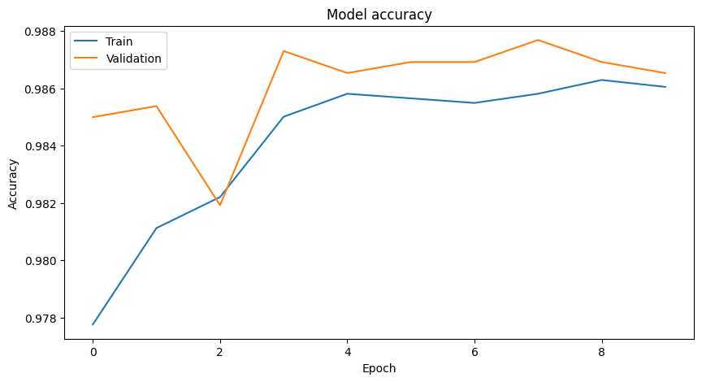

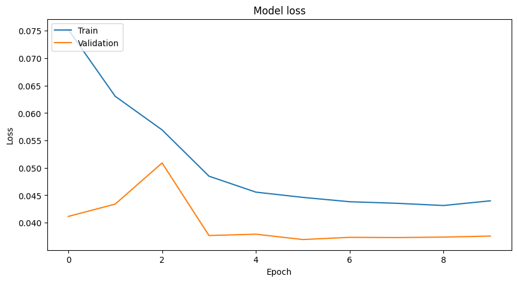

```python
import matplotlib.pyplot as plt

# plotting the accuracies and loss values

plt.figure(figsize=(10, 5))
plt.plot(history4.history['accuracy'])
plt.plot(history4.history['val_accuracy'])
plt.title('Model accuracy')
plt.ylabel('Accuracy')
plt.xlabel('Epoch')
plt.legend(['Train', 'Validation'], loc='upper left')
plt.show()

plt.figure(figsize=(10, 5))
plt.plot(history4.history['loss'])
plt.plot(history4.history['val_loss'])
plt.title('Model loss')
plt.ylabel('Loss')
plt.xlabel('Epoch')
plt.legend(['Train', 'Validation'], loc='upper left')
plt.show()
```

### **Observations and insights: The plot of the vgg16 model accuracy and loss shows the model's accuracy performed very well with an accuracy of 98% for both training and validation dataset, and for the loss, the model is doing well as the training and validation dataset decrease overtime within each epoch. This shows that the model is not overfitted and was trained well.**

- What can be observed from the validation and train curves?

### **Evaluating the model**

```python
loss, accuracy = model4.evaluate(test_dataset) # evaluating the model and printing the results
print(f"Validation Accuracy: {accuracy * 100:.2f}%")
```

```
Validation Accuracy: 98.65%
```

**Plotting the classification report and confusion matrix**

```python
import cv2
# resizing the test dataset to (64, 64, 3)
X_test_resized = np.array([cv2.resize(img, (64, 64)) for img in X_test_normalized])
```

```
              precision    recall  f1-score   support

 Parasitized       0.98      0.99      0.99      1300
  Uninfected       0.99      0.98      0.99      1300

    accuracy                           0.99      2600
   macro avg       0.99      0.99      0.99      2600
weighted avg       0.99      0.99      0.99      2600
```

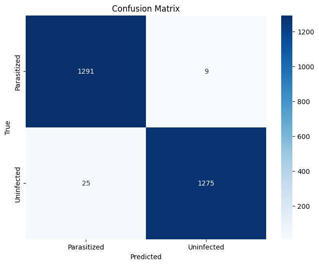

```python
import numpy as np
from sklearn.metrics import classification_report, confusion_matrix
import seaborn as sns
import matplotlib.pyplot as plt

# predicting the classes data
predictions = model4.predict(X_test_resized)
predicted_labels = np.argmax(predictions, axis=1)

# true labels
true_labels = np.argmax(y_test_one_hot, axis=1)

# classification report
report = classification_report(true_labels, predicted_labels, target_names=['Parasitized', 'Uninfected'])
print(report)

# confusion matrix
cm = confusion_matrix(true_labels, predicted_labels)
plt.figure(figsize=(8, 6))
sns.heatmap(cm, annot=True, fmt='d', cmap='Blues', xticklabels=['Parasitized', 'Uninfected'], yticklabels=['Parasitized', 'Uninfected'])
plt.xlabel('Predicted')
plt.ylabel('True')
plt.title('Confusion Matrix')
plt.show()
```

### **Think about it:**

- What observations and insights can be drawn from the confusion matrix and classification report?
- Choose the model with the best accuracy scores from all the above models and save it as a final model.

**Improvements that can be done:**

- Can the model performance be improved using other pre-trained models or different CNN architecture?
- You can try to build a model using these HSV images and compare them with your other models.

#### **Refined insights**:

- What are the most meaningful insights from the data relevant to the problem?

#### **Comparison of various techniques and their relative performance**:

- How do different techniques perform? Which one is performing relatively better? Is there scope to improve the performance further?

#### **Proposal for the final solution design**:

- What model do you propose to be adopted? Why is this the best solution to adopt?